# Data Scientist - Analytical Exercise - PaySafe

TimLin

10/18/2016

Data Sources: https://www.lendingclub.com/info/download-data.action  
Download 2015 Loan Data from the “Download Loan Data” section and load the data from csv file into R data frame, and check the dimension of the data:

```r
library(plyr)
library(ggplot2)
```

```r
setwd("~/data")
data<-read.csv("LoanStats3d.csv",header=TRUE,sep=",")
dim(data)
```

```
## [1] 421095    111
```

#### Set A

##### 1. Review the dataset and summarize your thoughts on any structural issues:

##### a. Is there missing data? Is the missing data random or structured: Are some attributes missing more than others?

```r
sum(is.na(data))
```

```
## [1] 7963782
```

There are total 7963782 missing data.

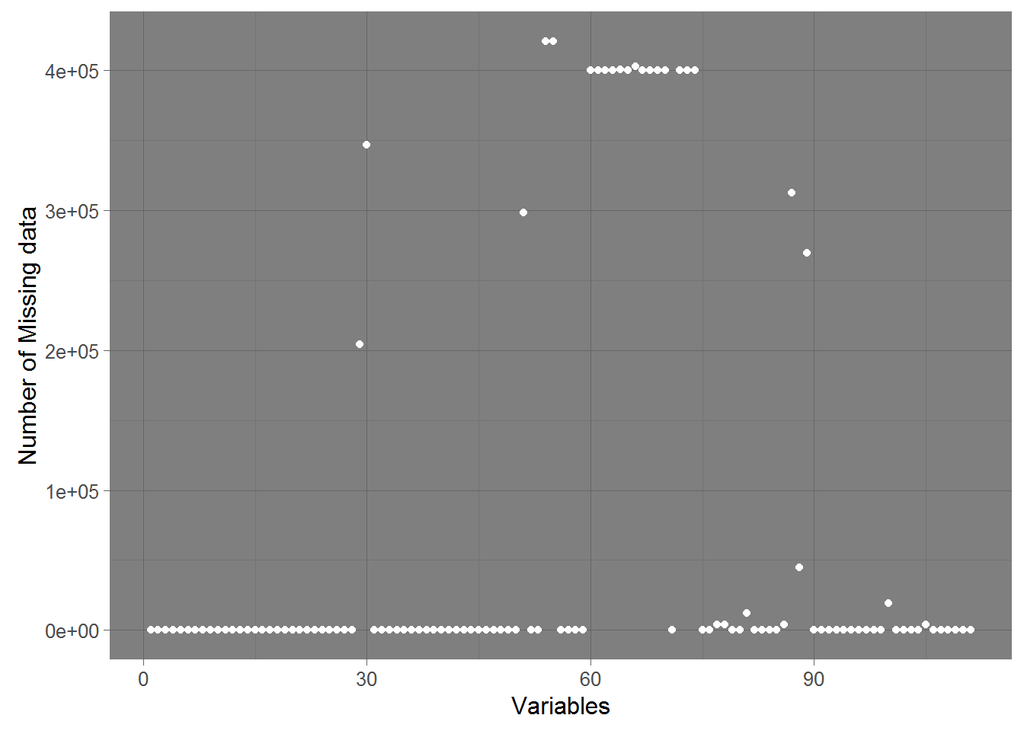

```r
missingdata<-sapply(data, function(x) sum(is.na(x)))
ggplot(NULL,aes(x=seq(1,ncol(data)),y=missingdata))+geom_point(col='white')+theme_dark()+xlab("Variables")+ylab("Number of Missing data")
```

From the scatter plot we can conclude that the missing data is structured, which means the number of missing values are skewed and occur in specific variables.

First, I would inspect those variables which have more than 380,000 missing data:

```r
names(data)[missingdata>380000]
```

```
##  [1] "annual_inc_joint"   "dti_joint"          "open_acc_6m"
##  [4] "open_il_6m"         "open_il_12m"        "open_il_24m"
##  [7] "mths_since_rcnt_il" "total_bal_il"       "il_util"
## [10] "open_rv_12m"        "open_rv_24m"        "max_bal_bc"
## [13] "all_util"           "inq_fi"             "total_cu_tl"
## [16] "inq_last_12m"
```

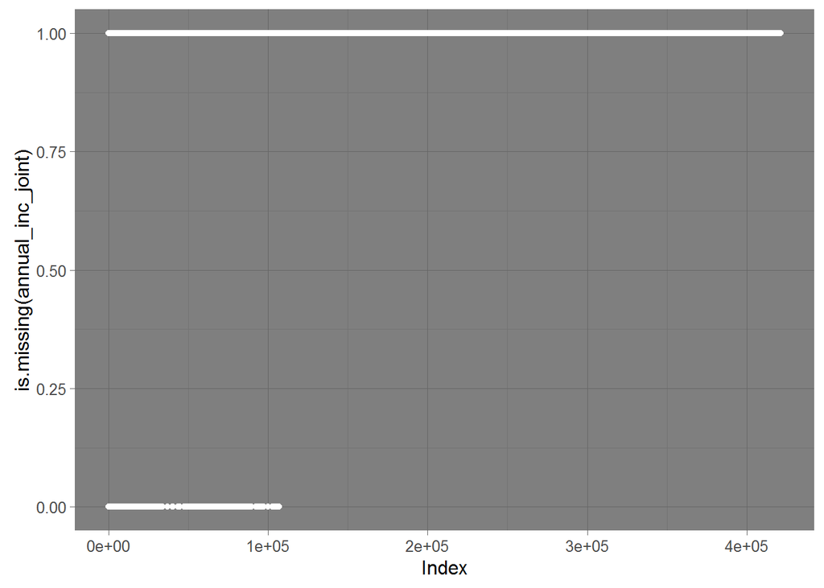

```r
# Plot two variables for sample
ggplot(NULL,aes(x=seq(1,nrow(data)),y=as.numeric(is.na(data$annual_inc_joint))))+geom_point(col='white')+theme_dark()+xlab("Index")+ylab("is.missing(annual_inc_joint)")
```

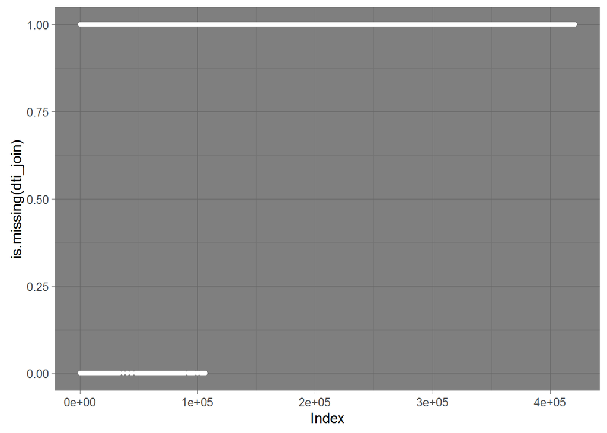

```r
ggplot(NULL,aes(x=seq(1,nrow(data)),y=as.numeric(is.na(data$dti_join))))+geom_point(col='white')+theme_dark()+xlab("Index")+ylab("is.missing(dti_join)")
```

Then, I will inspect those variables which have more than 150,000 but not more than 380,000 missing data:

```r
names(data)[missingdata<380000 & missingdata>150000]
```

```
## [1] "mths_since_last_delinq"         "mths_since_last_record"
## [3] "mths_since_last_major_derog"    "mths_since_recent_bc_dlq"
## [5] "mths_since_recent_revol_delinq"
```

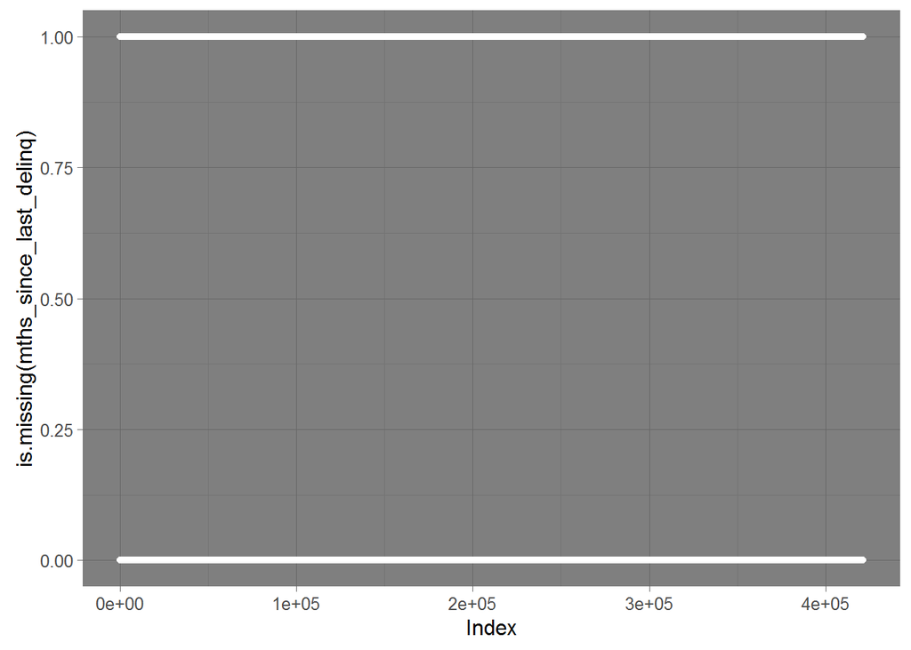

```r
# Plot two variables for sample
ggplot(NULL,aes(x=seq(1,nrow(data)),y=as.numeric(is.na(data$mths_since_last_delinq))))+geom_point(col='white')+theme_dark()+xlab("Index")+ylab("is.missing(mths_since_last_delinq)")
```

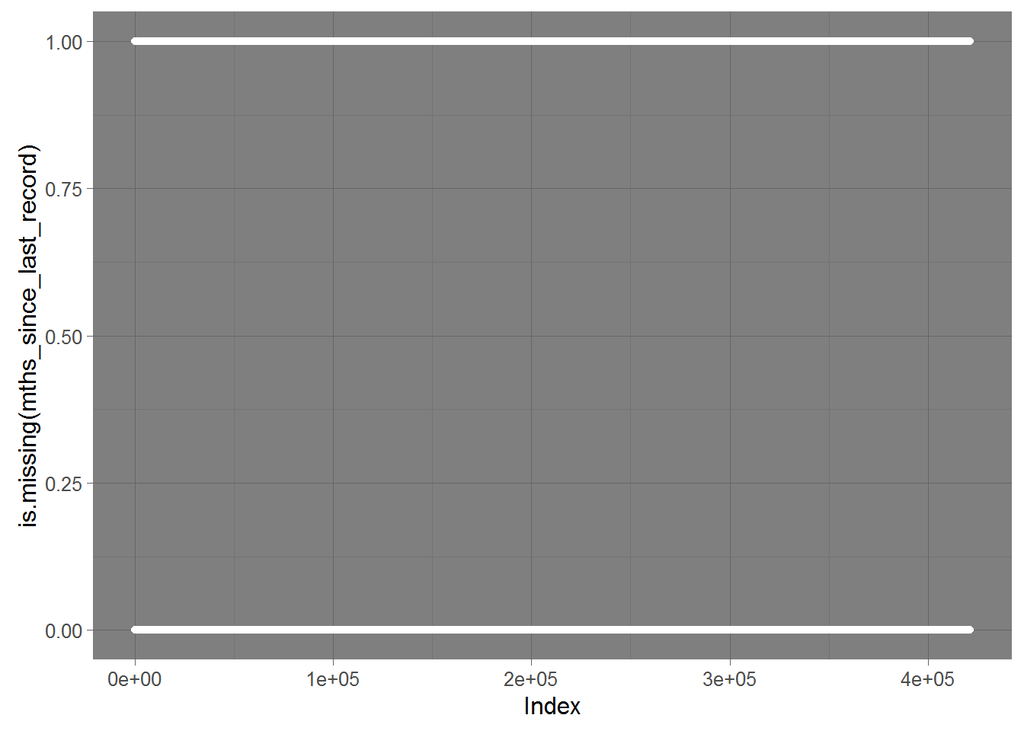

```r
ggplot(NULL,aes(x=seq(1,nrow(data)),y=as.numeric(is.na(data$mths_since_last_record))))+geom_point(col='white')+theme_dark()+xlab("Index")+ylab("is.missing(mths_since_last_record)")
```

By plotting the scatter plot with observations’ id and missing status, we discover that the missing data seems to be randomly generated without patterns. To discover the reason which caused missingdata, I will recommend discussing with a domain expert or make a thorough analysis between these variables and others. Make sure to figure out the reason that caused the missing data and make a suitable decision to handle this data, e.g. delete it, replace by a fix values, impute it by model or impute it by means, etc.

##### b. Are any data values glaringly erroneous?

Generally, I will check if there are any glaringly erroneous data by screening data with following features: (1) Out-of-range values (2) Unconsistant data (3) Duplicate or redundant cases: No (4) Empty cases (5) Missing value (6) Outliers

In this case, I will make a quick screen of the summary of each variable first:

```r
summary(data)
```

```
##        id             member_id          loan_amnt      funded_amnt
##  Min.   :   56705   Min.   :   70825   Min.   : 1000   Min.   : 1000
##  1st Qu.:46124814   1st Qu.:49226166   1st Qu.: 8500   1st Qu.: 8500
##  Median :55360307   Median :58953580   Median :14000   Median :14000
##  Mean   :53930969   Mean   :57595756   Mean   :15240   Mean   :15240
##  3rd Qu.:61862166   3rd Qu.:66045844   3rd Qu.:20000   3rd Qu.:20000
##  Max.   :68617057   Max.   :73544841   Max.   :35000   Max.   :35000
##
##  funded_amnt_inv         term           int_rate       installment
##  Min.   :  900    36 months:283173   7.89%  : 20306   Min.   :  23.4
##  1st Qu.: 8500    60 months:137922   9.17%  : 20058   1st Qu.: 263.9
##  Median :14000                       10.99% : 19782   Median : 385.4
##  Mean   :15234                       9.99%  : 19615   Mean   : 441.9
##  3rd Qu.:20000                       12.29% : 18546   3rd Qu.: 578.8
##  Max.   :35000                       12.69% : 18010   Max.   :1445.5
##                                      (Other):304778
##  grade        sub_grade                 emp_title          emp_length
##  A: 73336   C1     : 26434                   : 23872   10+ years:141521
##  B:117606   C2     : 25496   Teacher         :  8070   2 years  : 37497
##  C:120567   B4     : 25121   Manager         :  6802   < 1 year : 34340
##  D: 62654   C3     : 24844   Owner           :  3849   3 years  : 33429
##  E: 34948   C4     : 24752   Registered Nurse:  3209   1 year   : 27473
##  F:  9817   B3     : 24637   RN              :  3151   5 years  : 24930
##  G:  2167   (Other):269811   (Other)         :372142   (Other)  :121905
##   home_ownership     annual_inc          verification_status
##  65000   :     1   60000  : 16301   Not Verified   :118513
##  ANY     :     2   50000  : 14626   Nov-15         :     1
##  MORTGAGE:207683   65000  : 12286   Source Verified:179565
##  OWN     : 45766   70000  : 11685   Verified       :123016
##  RENT    :167643   80000  : 11088
##                    40000  : 11079
##                    (Other):344030
##     issue_d                   loan_status
##  Oct-15 : 48631   Current           :320744
##  Jul-15 : 45962   Fully Paid        : 65231
##  Dec-15 : 44343   Charged Off       : 18449
##  Nov-15 : 37529   Late (31-120 days):  9441
##  Aug-15 : 35886   In Grace Period   :  5260
##  Apr-15 : 35427   Late (16-30 days) :  1896
##  (Other):173317   (Other)           :    74
```

[output cut: 217 more lines]

```
##  Min.   : 0.0000      Min.   :    0.00   Min.   :   2500
##  1st Qu.: 0.0000      1st Qu.:    0.00   1st Qu.:  50908
##  Median : 0.0000      Median :    0.00   Median : 111405
##  Mean   : 0.1332      Mean   :    0.22   Mean   : 173407
##  3rd Qu.: 0.0000      3rd Qu.:    0.00   3rd Qu.: 249629
##  Max.   :11.0000      Max.   :64944.00   Max.   :9999999
##
##  total_bal_ex_mort total_bc_limit   total_il_high_credit_limit
##  Min.   :      0   Min.   :     0   Min.   :      0
##  1st Qu.:  22598   1st Qu.:  7800   1st Qu.:  15481
##  Median :  39596   Median : 15200   Median :  32970
##  Mean   :  52222   Mean   : 21958   Mean   :  43479
##  3rd Qu.:  65651   3rd Qu.: 28600   3rd Qu.:  58299
##  Max.   :2921551   Max.   :834300   Max.   :2101913
##                                     NA's   :1
```

Check duplicate or empty cases:

```r
sum(as.numeric(duplicated(data))) #check duplicate case
```

```
## [1] 0
```

```r
sum(as.numeric(rowSums(is.na(data))==ncol(data))) #check empty case
```

```
## [1] 0
```

There are no duplicate and empty cases.

Then I inspect the non-reasonable outliers by graph analysis:

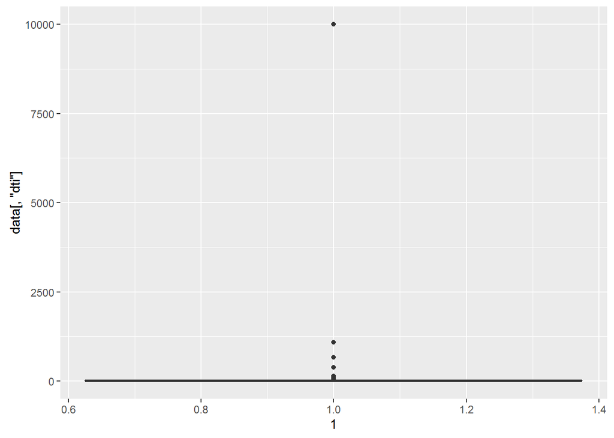

```r
#Take dti as an example:
qplot(y=data[,"dti"], x= 1, geom = "boxplot")
```

I noticed that dti column have two variables = 9999, which may be outliers that need to be handled.

##### 2. Summarize the types of “loan_status” presented in the LC dataset (e.g. frequency of types, etc).

```r
summary(data$loan_status)
```

```
##        Charged Off            Current            Default
##              18449             320744                 73
##         Fully Paid    In Grace Period  Late (16-30 days)
##              65231               5260               1896
## Late (31-120 days)                  n
##               9441                  1
```

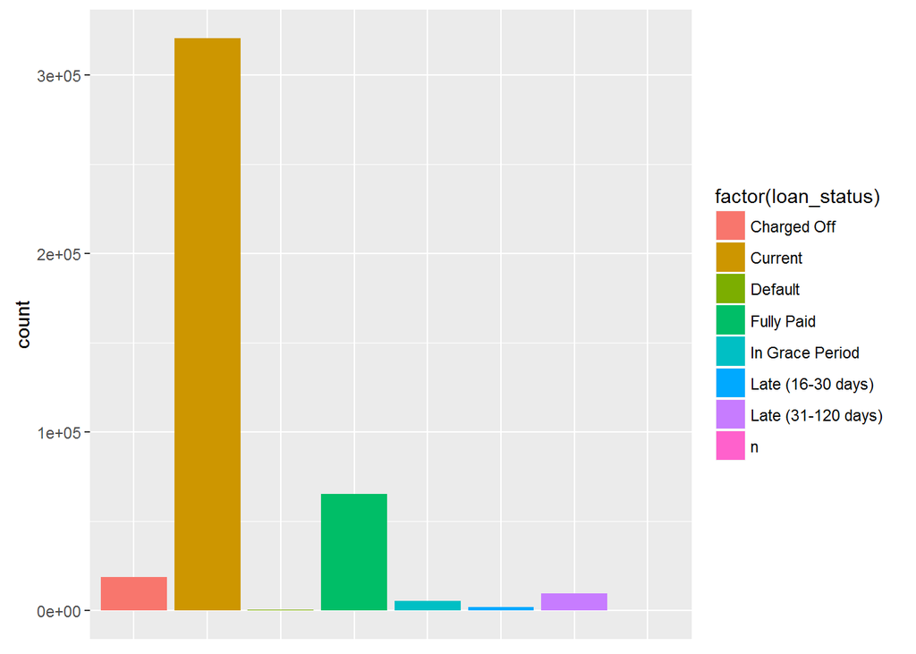

```r
ggplot(data,aes(x=factor(loan_status),fill=factor(loan_status)))+geom_bar()+theme(axis.title.x=element_blank(),axis.text.x=element_blank(),axis.ticks.x=element_blank())+xlab("Factors")+ylab("count")
```

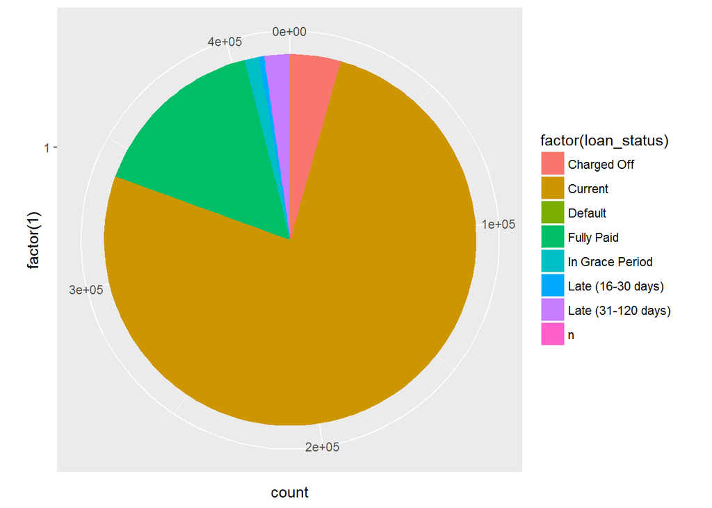

```r
pie <- ggplot(data, aes(x = factor(1), fill = factor(loan_status))) + geom_bar(width = 1)
pie + coord_polar(theta = "y")
```

```r
round(summary(data$loan_status)/sum(summary(data$loan_status))*100,2)
```

```
##        Charged Off            Current            Default
##               4.38              76.17               0.02
##         Fully Paid    In Grace Period  Late (16-30 days)
##              15.49               1.25               0.45
## Late (31-120 days)                  n
##               2.24               0.00
```

From the bar chart and pie chart, we can notice that there are more than 75% of loan_status that belong to “Current”. Furthermore, the percentage of “bad loan” (Charged Off + Default) is around 4.4%.

##### 3. Using loan status of Charged Off, Default, as indicators of a “bad loans”, describe the predictive relationship of earliest_cr_line, annual_inc, and dti on probability of default..

1. loan status VS earliest_cr_line

```r
# Indicate the good and bad loans factor.
datapredict <- data[,c("loan_status","earliest_cr_line","annual_inc","dti")]
datapredict$loan_status <- factor(as.numeric(datapredict$loan_status %in% c("Charged Off", "Default")))
datapredict$annual_inc<-as.numeric(levels(datapredict$annual_inc))[datapredict$annual_inc]
```

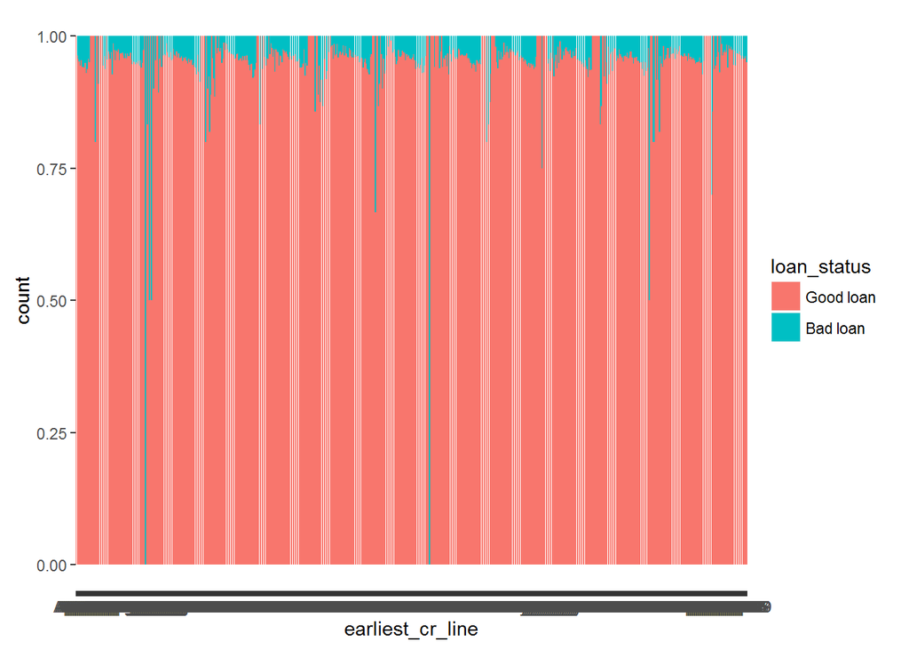

```r
datapredict$loan_status<-mapvalues(datapredict$loan_status, from = c(0, 1), to = c("Good loan", "Bad loan"))

ggplot(datapredict,aes(x=earliest_cr_line))+ geom_bar(aes(fill = loan_status, stat = "identity"), position = "fill")
```

2. loan status VS annual_inc

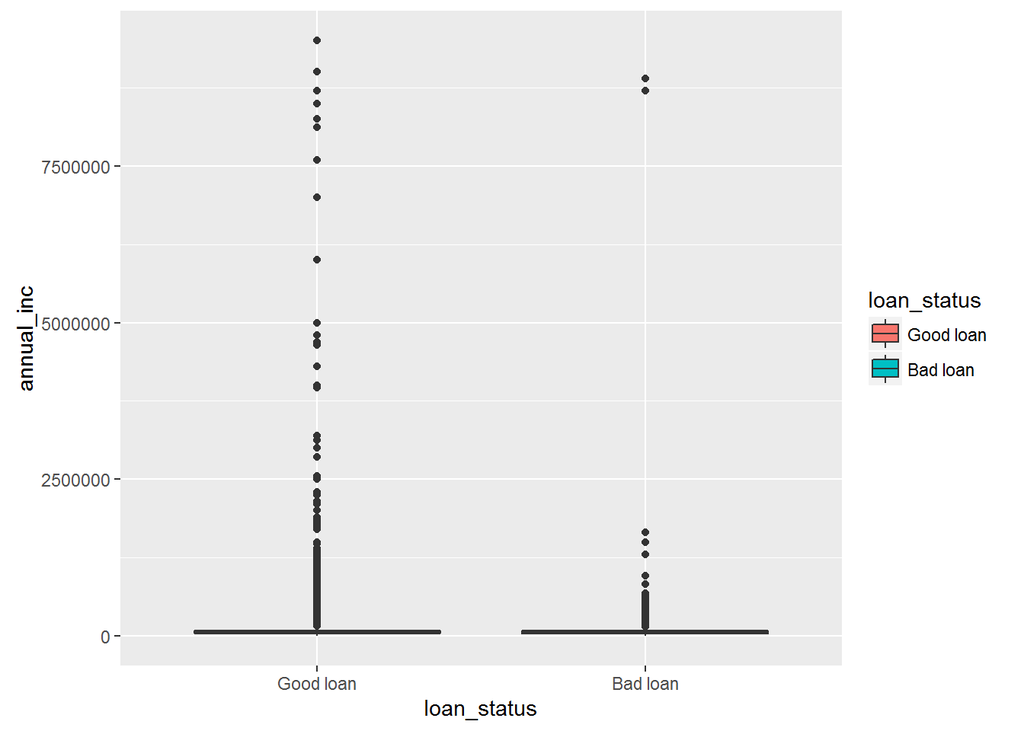

```r
ggplot(datapredict,aes(x=loan_status,y=annual_inc,fill=loan_status))+geom_boxplot()
```

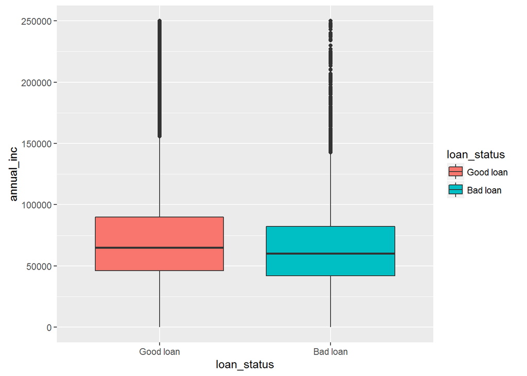

```r
ggplot(datapredict,aes(x=loan_status,y=annual_inc,fill=loan_status))+geom_boxplot()+ylim(0,250000)
```

```r
summary(aov(annual_inc~loan_status, datapredict))
```

```
##                 Df    Sum Sq   Mean Sq F value Pr(>F)
## loan_status      1 9.039e+11 9.039e+11   165.3 <2e-16 ***
## Residuals   421092 2.302e+15 5.466e+09
## ---
## Signif. codes:  0 '***' 0.001 '**' 0.01 '*' 0.05 '.' 0.1 ' ' 1
## 1 observation deleted due to missingness
```

It seems like good loan has a little bit more higher annual_inc compared to bad loan, but both of them have high variety, especially good loan. To be aware that bad loan has few obvious outliers, I will recommend taking it off making any prediction. Moreover, ANOVA testing shows that the relationship between these two variables as significant.

3. loan status VS dti

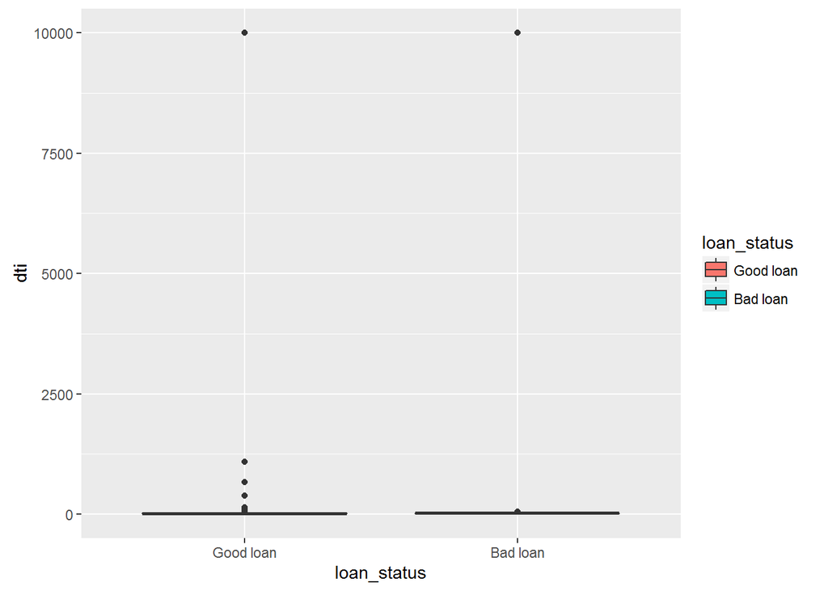

```r
ggplot(datapredict,aes(x=loan_status,y=dti,fill=loan_status))+geom_boxplot()
```

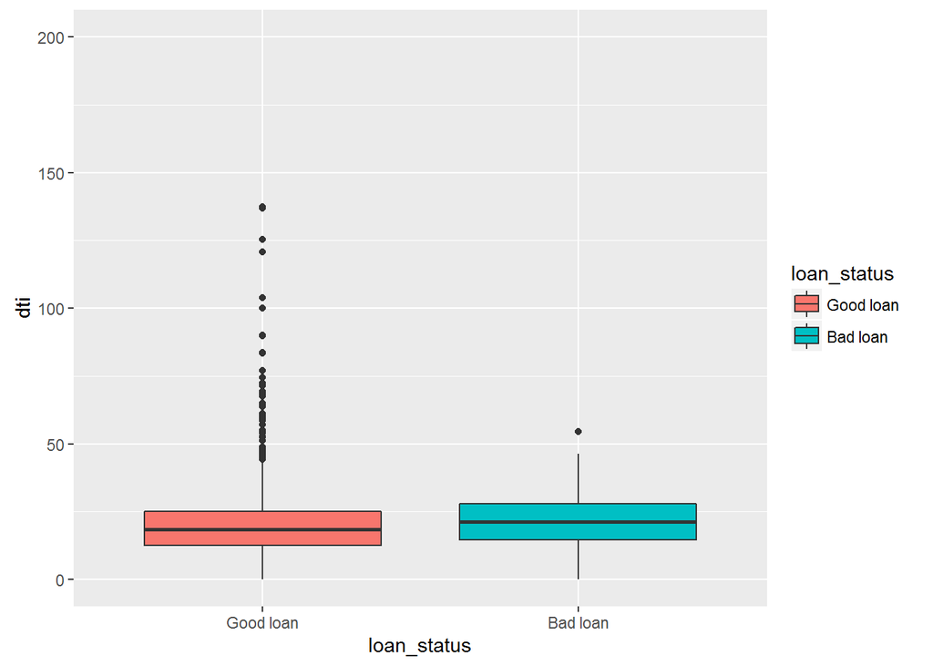

```r
ggplot(datapredict,aes(x=loan_status,y=dti,fill=loan_status))+geom_boxplot()+ylim(0,200)
```

```r
summary(aov(dti~loan_status, datapredict))
```

```
##                 Df    Sum Sq Mean Sq F value Pr(>F)
## loan_status      1    129114  129114   233.8 <2e-16 ***
## Residuals   421093 232500326     552
## ---
## Signif. codes:  0 '***' 0.001 '**' 0.01 '*' 0.05 '.' 0.1 ' ' 1
```

##### 4. What is the frequency of “bad loan” within the grades provided by the lending club? Provide a graphic summarizing your results. How do you interpret these results?

```r
datagrade <- data[,c("loan_status","grade","sub_grade")]
datagrade$loan_status <- factor(as.numeric(datagrade$loan_status %in% c("Charged Off", "Default")))
datagrade$loan_status<-mapvalues(datagrade$loan_status, from = c(0, 1), to = c("Good loan", "Bad loan"))
summary(datagrade$loan_status)
```

```
## Good loan  Bad loan
##    402573     18522
```

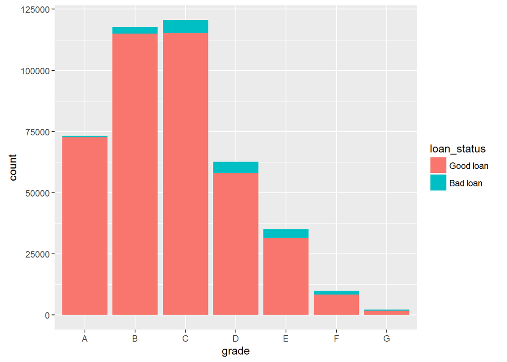

```r
qplot(grade, data=datagrade, geom="bar", fill=loan_status)
```

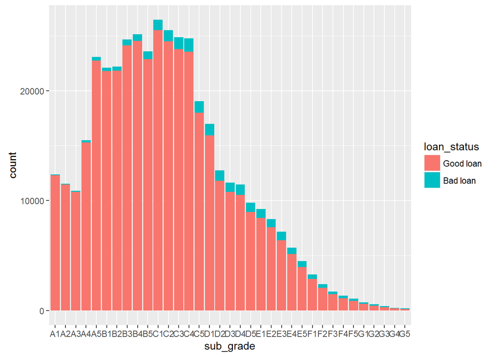

```r
qplot(sub_grade, data=datagrade, geom="bar", fill=loan_status)
```

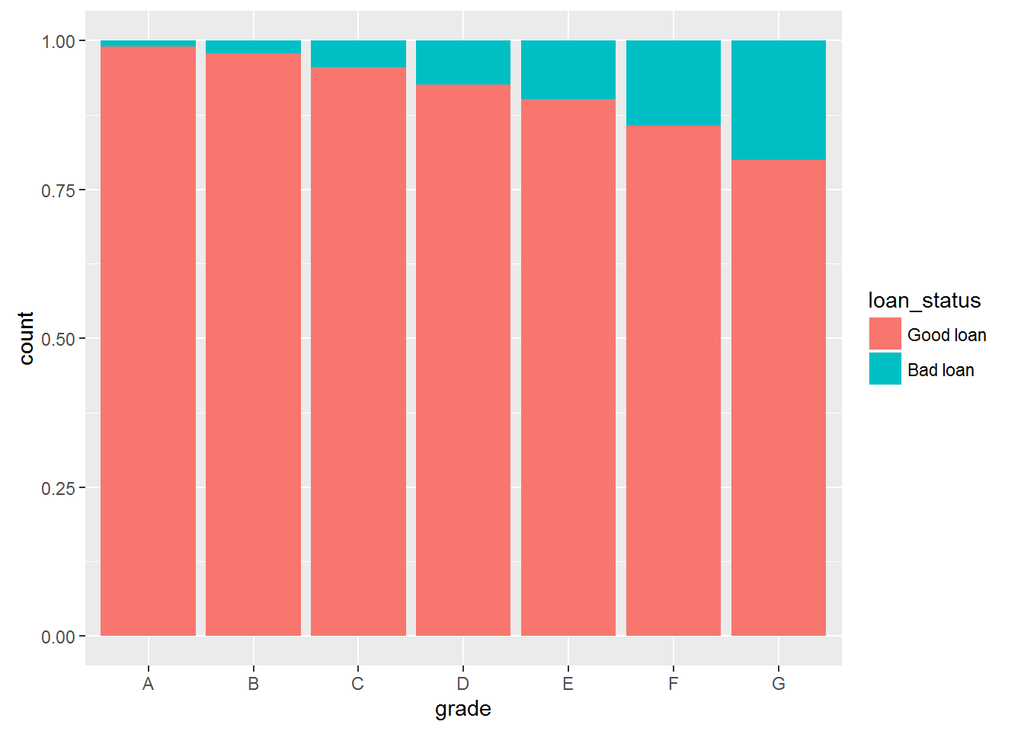

```r
ggplot(datagrade,aes(x=grade))+ geom_bar(aes(fill = loan_status, stat = "identity"), position = "fill")
```

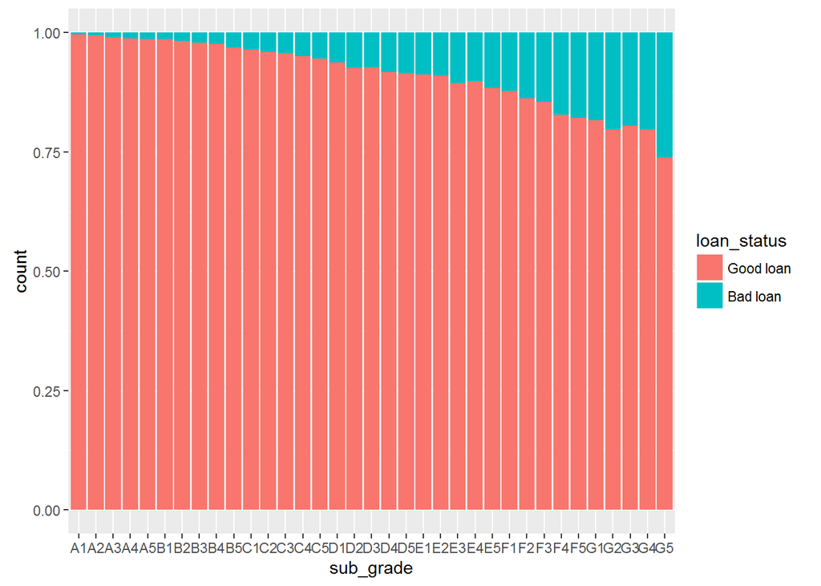

```r
ggplot(datagrade,aes(x=sub_grade))+ geom_bar(aes(fill = loan_status, stat = "identity"), position = "fill")
```

By looking at the graph, we can see the grade/sub_grade decrease from A to G and the probability of bad loan increase.

##### 5. Select one of the below topics and explain it to:

linear regression

##### a. Someone with significant mathematical experience, and

The linear regression model is used to detect and explain the relationship between one dependent variable from another or more independent variables. The dependent variables should be continuous and independent variables can be continuous or categorical. It is often used for explanatory analysis and prediction. The major goal of linear regression is to fit a line through a multi-dimensional cloud of data points with the formula of:

Y=B0+B1X1+B2X2+…+BnXn

Y is the dependent variable and Xi is independent variables, the slopes of independent variables’ individual straight-line relationships with dependent variable are the constants B1, B2, …, Bk. The coefficents imply the change in Y per unit of change in Xi. B0 is the intercept, which implies the value of Y when every xi = 0. The coefficients have been estimated by minimizing the least squares error of the outcome.

There are four major assumptions that have to be satisfied before using linear regression:  
(1) The mean of the response variable is linear related to the predictors.  
(2) The error terms(residual) are normally distributed.  
(3) The error terms(residual) have equal variances.  
(4) The error terms(residual) are independent at each preditor value.

Usually, we use the p-value of each predictors to evaluate the significance of relation from Xi to Y, and a smaller p-value implies a strong significant relationship. To evaluate the Goodness-of-fit, we usually use R-square index, which is the square of the correlation between the observed Y values and the predicted values. The higher the R-square is, a more powerful fit the model has.

##### b. Someone with little mathematical experience. You can use graphics/diagrams if you wish.

The basic principle of linear regression is that we have to find a line or a hyperplan which can best describe the relationship betweeen Xi and Y. For example, in an image we have two variables, X and Y, and there is a linear relation beween them. We can demonstrate this by using installment and loan_amount variables in LC data:

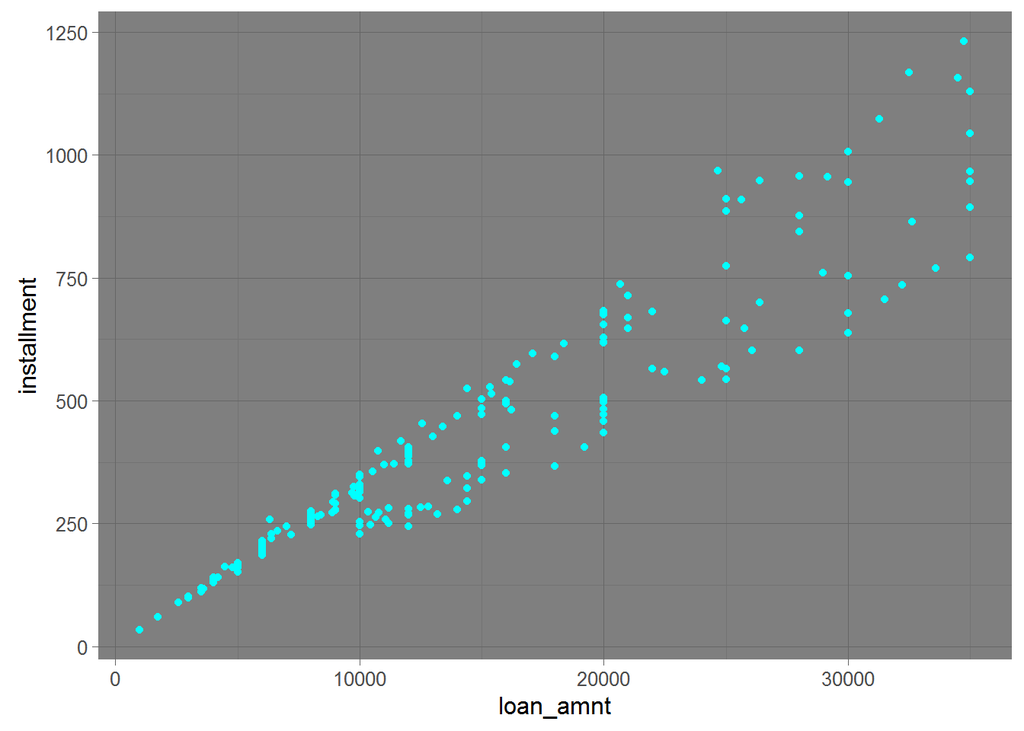

```r
set.seed(1)
p<-sample(nrow(data),200)
datademo<-data[p,]
g<-ggplot(datademo,aes(x=loan_amnt,y=installment))+geom_point(col="5")+theme_dark()
g
```

Our goal is to try to find a line in a 2-dimensional space which can best fit the linear relation between X and Y as follows:

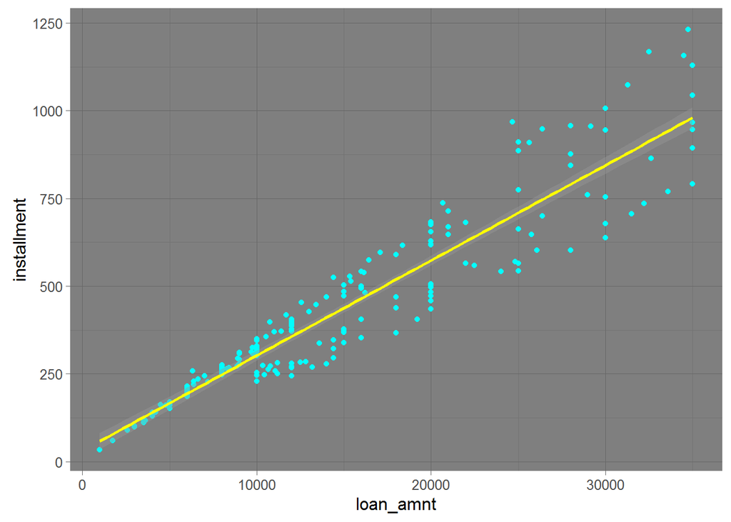

```r
g+geom_smooth(method="lm",col="7")
```

“Find the line” means we have to define the coefficent of the line, which means B0 and B1 in the line’s function:

Y=B0+B1X1

Let’s see the coefficent in this case:

```r
fit<-lm(installment~loan_amnt,data=datademo)
summary(fit)
```

```
##
## Call:
## lm(formula = installment ~ loan_amnt, data = datademo)
##
## Residuals:
##      Min       1Q   Median       3Q      Max
## -207.004  -59.859    8.261   44.743  268.013
##
## Coefficients:
##              Estimate Std. Error t value Pr(>|t|)
## (Intercept) 31.110027  12.356487   2.518   0.0126 *
## loan_amnt    0.027106   0.000698  38.835   <2e-16 ***
## ---
## Signif. codes:  0 '***' 0.001 '**' 0.01 '*' 0.05 '.' 0.1 ' ' 1
##
## Residual standard error: 88.46 on 198 degrees of freedom
## Multiple R-squared:  0.884,  Adjusted R-squared:  0.8834
## F-statistic:  1508 on 1 and 198 DF,  p-value: < 2.2e-16
```

```r
round(summary(fit)$coef,2)
```

```
##             Estimate Std. Error t value Pr(>|t|)
## (Intercept)    31.11      12.36    2.52     0.01
## loan_amnt       0.03       0.00   38.84     0.00
```